# Computational Methods for Hypothesis Testing and Sampling Distributions

Statistical Computing for Data Analysis

# Earlier Material

- how to simulate from distributions
- how to estimate expectations/probabilities
- how to sample efficiently

# New question

Now we shift to using simulation for statistical inference.

How can we use repeated simulations (sometimes known as resampling) to carry out **hypothesis testing** and understanding **sampling distributions**

- **Before**: simulate random *observations* or *data values* from a target distribution.
- **Now**: simulate *statistics*
- **Goal**: approximate the distribution of a (test) statistic. This distribution is known as a sampling distribution.

# What is a sampling distribution?

Suppose we repeatedly drawn samples of size $n$ from the same population. Then for each sample, we compute a statistic, such as:

- the sample mean $\bar{X}$
- the sample proportion $\hat{p}$
- the sample median
- the difference in two sample means

Note that **a statistic is random because the sample is random.** Therefore it has a distribution. This distribution is called a **sampling distribution**.

The **sampling distribution** is the distribution of that statistic over repeated samples.

Example: If we repeatedly sample $n = 25$ observations and compute $\bar{X}$ each time, the value of $\bar{X}$ will vary from sample to sample (i.e. the statistic $\bar{X}$ is random).

The distribution of $\bar{X}$ is the sampling distribution of the sample mean.

# Population distribution vs. sampling distribution

**Population distribution**: Describes the distribution of individual data values or observations in the population.

This is the distribution we were targeting when we used:

- the inverse CDF method
- rejection sampling
- importance sampling or sampling importance resampling

**Sampling distribution**: Describes the distribution of a statistic computed from repeated samples.

- Earlier: simulate **observations** from a population distribution
- Now: study the distribution of a **statistic** built from those observations

$$\text{Population distribution}
\;\longrightarrow\;
\text{draw a sample } X_1,\dots,X_n
\;\longrightarrow\;
\text{compute a statistic } T(X_1,\dots,X_n)$$

If we repeat this process many times, the resulting values of $T$ form the **sampling distribution** of the statistic.

# Illustration

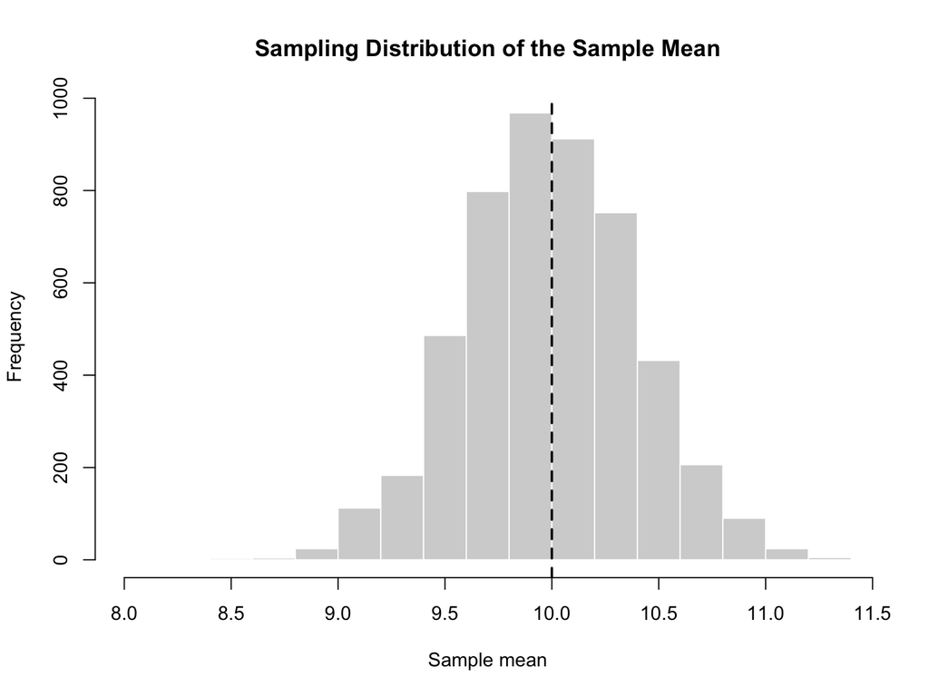

```r
set.seed(4279)

# Settings
n <- 25          # sample size
B <- 5000        # number of repeated samples

# Store the sample means
sample_means <- numeric(B)

# Repeated sampling
for (b in 1:B) {
  x <- rnorm(n, mean = 10, sd = 2)   # draw one sample from the population
  sample_means[b] <- mean(x)         # compute the statistic
}

# View the sampling distribution
hist(sample_means,
     main = "Sampling Distribution of the Sample Mean",
     xlab = "Sample mean",
     col = "lightgray",
     border = "white")

# Compare to the population mean
abline(v = 10, lwd = 2, lty = 2)
```

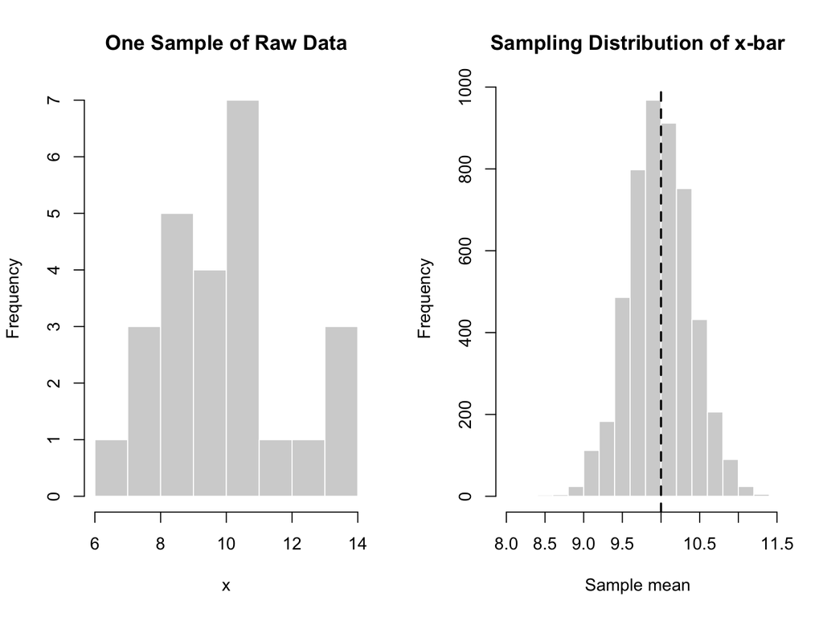

```r
set.seed(123)

# One sample from the population
x <- rnorm(25, mean = 10, sd = 2)

par(mfrow = c(1, 2))

hist(x,
     main = "One Sample of Raw Data",
     xlab = "x",
     col = "lightgray",
     border = "white")

hist(sample_means,
     main = "Sampling Distribution of x-bar",
     xlab = "Sample mean",
     col = "lightgray",
     border = "white")

abline(v = 10, lwd = 2, lty = 2)
```

# Why do we care about sampling distributions?

Sampling distributions tell us how much a statistic varies from sample to sample. They help us answer questions like:

- How much uncertainty is there in my estimate?
- How can I compute a standard error?
- How can I construct a confidence interval?
- How can I test a hypothesis?

Let’s focus on this last bullet point.

Now we understand sampling distributions, how do we use these sampling distributions to carry out statistical inference (i.e. hypothesis tests)?

# From sampling distribution to inference

Suppose we want to compare two groups. A natural choice of statistic is

$$T = \bar X_1 - \bar X_2$$

which measures the difference in sample means. We could also standardize this $T$ by dividing by its standard error.

We now ask:

**Is this observed value large enough that it suggests a real effect, or could it reasonably have occurred just by chance?**

Let’s say we calculate that $T$ is 0.5. Does this suggest a real effect? What if $T=2$ or $T= -1.5$. How large does $|T|$ need to be to suggest a real difference between $\bar X_1$ and $\bar X_2$?

How do we answer this in a statistically principled way?

# From a statistic to a null distribution

Suppose we want to compare two groups, and we use

$$T = \bar X_1 - \bar X_2$$

to measure the difference between their sample means.

This quantity $T$ is called a **test statistic**.

Once we compute the observed value of $T$, the next question is:

**Is this difference large enough to suggest a real effect, or could it have happened just by chance?**

To answer that, we need a **reference distribution** for $T$.

In hypothesis testing, the reference distribution is the distribution of $T$ when the **null hypothesis is true**.

This is called the **null distribution**.

### Think back

Up to this point in your statistics courses, how did you usually determine the null distribution?

# Why the null distribution matters

Suppose our test statistic is

$$T = \bar X_1 - \bar X_2$$

and our observed value is

$$T_{\text{obs}} = 4.2.$$

By itself, the number $4.2$ does not tell us very much.

Its meaning depends on the reference distribution:

- if values around $4.2$ are common under the null, then this is not very surprising
- if values around $4.2$ are very rare under the null, then this is evidence against $H_0$.

# Hypothesis testing workflow

The basic logic is:

1. Determine your null hypothesis and alternative hypothsis.
2. Compute a test statistic (evidence from your data)
3. Determine its distribution under the null
4. Check whether the observed value is unusual (decision rule: p-value or rejection region)

### Guiding question

If the null hypothesis were true, how likely would it be to see a statistic this extreme?

This is what leads to:

- null distributions
- $p$-values
- rejection regions

# Where do null distributions come from?

Sometimes we can derive the null distribution mathematically.

Examples you have seen before:

- normal distributions
- $t$ distributions
- chi-square distributions

But in many problems, the null distribution is difficult to obtain analytically.

That is where **simulation** and **resampling** become useful.

# Transition to resampling

If the null distribution is hard to derive, we can approximate it by repeated computation.

This leads naturally to methods such as:

- Monte Carlo simulation under $H_0$
- permutation tests

Later we will talk about general distributions needed for inference, which will include methods like jackknife and bootstrap

# Monte Carlo simulation under $H_0$

Recap:

- A **sampling distribution** describes how a statistic varies over repeated samples.
- In hypothesis testing, we care about the sampling distribution of the test statistic **when the null hypothesis is true**.
- That sampling distribution is called the **null distribution**.

### Main idea

If we know what the data should look like under $H_0$, we can:

1. simulate many samples under $H_0$
2. compute the test statistic for each sample
3. use the resulting values to approximate the null distribution

# Example: Monte Carlo null distribution

Suppose we want to test

$$H_0: \mu = 10$$

using the test statistic

$$T = \bar X.$$

If $H_0$ is true and the population is Normal with standard deviation $\sigma = 2$, then we can:

- repeatedly simulate samples from $N(10, 2^2)$
- compute $\bar X$ for each sample
- use the simulated values of $\bar X$ to approximate the null distribution of $T$

Then we compare our observed statistic to this simulated null distribution.

This is called **Monte Carlo simulation under $H_0$**.

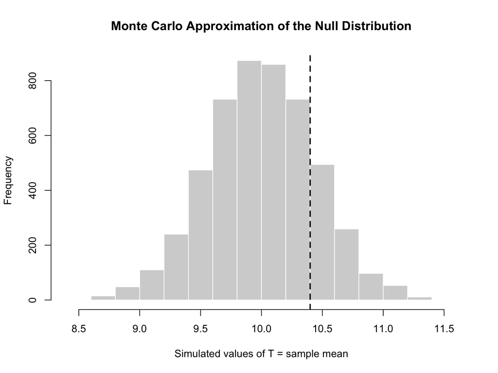

```r
set.seed(123)

# Observed data
x_obs <- c(10.8, 9.7, 10.5, 11.1, 9.9, 10.4, 10.2, 10.7,
           9.8, 10.9, 10.1, 10.6, 11.0, 9.6, 10.3, 10.8,
           10.0, 10.5, 10.4, 10.7)

# Observed test statistic
T_obs <- mean(x_obs)

# Null hypothesis: mu = 10
mu0 <- 10
sigma <- 2
n <- length(x_obs)
B <- 5000

# Monte Carlo simulation under H0
T_null <- numeric(B)

for (b in 1:B) {
  x_sim <- rnorm(n, mean = mu0, sd = sigma)
  T_null[b] <- mean(x_sim)
}

# Plot simulated null distribution
hist(T_null,
     main = "Monte Carlo Approximation of the Null Distribution",
     xlab = "Simulated values of T = sample mean",
     col = "lightgray",
     border = "white")

abline(v = T_obs, lwd = 2, lty = 2)
```

```r
# Two-sided Monte Carlo p-value
p_val <- mean(abs(T_null - mu0) >= abs(T_obs - mu0))
p_val
```

```
## [1] 0.3608
```

# When we do not know the null distribution

Sometimes we do **not** know the distribution of the data under $H_0$ well enough to simulate new datasets from a null model.

So instead of generating new data from a known null distribution, we use the **observed data** to construct a reference distribution.

### Main idea

Under the null hypothesis, the observed data often satisfy some kind of **exchangeability** or **relabeling symmetry**.

This means that, if $H_0$ is true, certain rearrangements of the data should not change the distribution of the test statistic under $H_0$.

So we can:

1. keep the observed data values fixed
2. rearrange or reassign part of the data in a way justified by $H_0$
3. recompute the test statistic each time
4. use the resulting values to approximate the null distribution

This gives a **permutation distribution**, which is a data-based approximation to the null distribution.

### Examples

- In a two-sample problem, we may permute (shuffle) **group labels**
- In a correlation problem, we may permute one variable relative to the other
- In a regression problem, we may permute the response relative to the predictor

# Permutation as a data-based null distribution

Suppose we want to test whether two groups differ, using

$$T = \bar X_1 - \bar X_2.$$

If we do **not** know the data distribution under $H_0$, we need another way to approximate the null distribution of $T$.

In this two-sample test setting, we are testing: $H_0: \mu_1 = \mu_2$ versus $H_1: \mu_1 \neq \mu_2$. So under the null hypothesis of **no group difference**, the group labels are interchangeable.

So we:

- keep the observed data values fixed
- permute (shuffle) the labels many times
- recompute $T$ after each shuffle

The resulting distribution of these shuffled statistics is the **permutation distribution**.

We use this as a data-based null distribution for hypothesis testing.